# Question

Tyler has a 22% chance to hit each freethrow (so $p=0.22$). Each freethrow is [independent](https://en.wikipedia.org/wiki/Independent_and_identically_distributed_random_variables).

Each day, Tyler attempts $n=70$ freethrows. Each success gets 1 point. Each failure gets 0 points.

We can predict the distribution of points per day . We will use 2 strategies:

- An exact [binomial distribution](https://en.wikipedia.org/wiki/Binomial_distribution).
- A normal approximation.

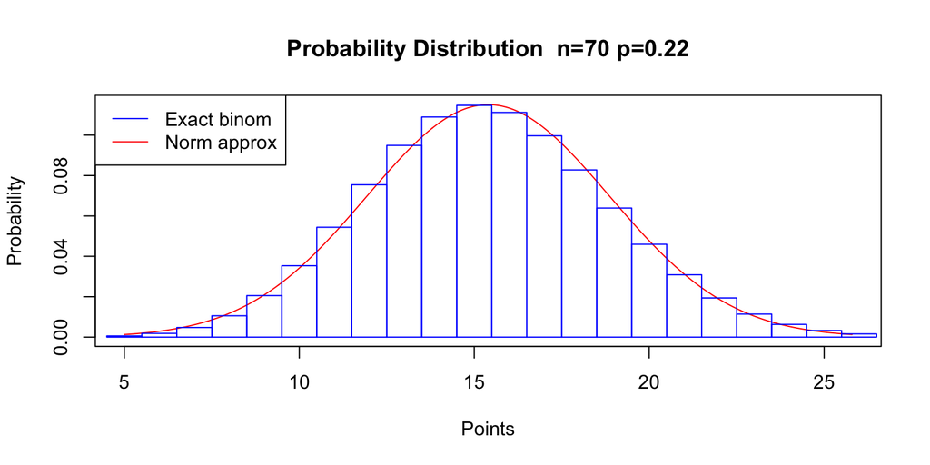

- We can set up the exact binomial in [Desmos](https://www.desmos.com/calculator) using `binomialdist(70,0.22)`

To set up the normal approximation, we need to find the mean and the standard deviation.

$$\mu = np$$
$$\sigma = \sqrt{np(1-p)}$$

- Once you get $\mu$ and $\sigma$, you can set up the normal approximation in [Desmos](https://www.desmos.com/calculator) using `normaldist(`$\mu$`,`$\sigma$`)`

Please find the following probabilities:

1. Using the exact binomial, calculate $P(X<20.5)$. ##ANSWER1##
2. Using the normal approximation, calculate $P(X<20.5)$. ##ANSWER2##
3. Using the exact binomial, calculate $P(X>20.5)$. ##ANSWER3##
4. Using the normal approximation, calculate $P(X>20.5)$. ##ANSWER4##
5. Using the exact binomial, calculate $P(9.5<X<16.5)$. ##ANSWER5##
6. Using the normal approximation, calculate $P(9.5<X<16.5)$. ##ANSWER6##

*(Notice I already gave [half-integer](https://en.wikipedia.org/wiki/Half-integer) boundaries for the [continuity correction](https://en.wikipedia.org/wiki/Continuity_correction).)*

## Answerlist

- 0.071
- 0.074
- 0.580
- 0.595
- 0.926
- 0.929
- 0.071
- 0.074
- 0.580
- 0.595
- 0.926
- 0.929
- 0.071
- 0.074
- 0.580
- 0.595
- 0.926
- 0.929
- 0.071
- 0.074
- 0.580
- 0.595
- 0.926
- 0.929
- 0.071
- 0.074
- 0.580
- 0.595
- 0.926
- 0.929
- 0.071
- 0.074
- 0.580
- 0.595
- 0.926
- 0.929

# Solution

### Answers

1. Exact: $P(X<20.5)=0.926$
2. Approx: $P(X<20.5)\approx0.929$
3. Exact: $P(X>20.5)=0.074$
4. Approx: $P(X>20.5)\approx0.071$
5. Exact: $P(9.5<X<16.5)=0.595$
6. Approx: $P(9.5<X<16.5)\approx0.580$

### How to: first find $\mu$ and $\sigma$ for normal approximation

$$\mu ~=~ pn ~=~ (0.22)(70) ~=~
15.4$$

$$\sigma ~=~ \sqrt{np(1-p)} ~=~
\sqrt{(70)(0.22)(1-0.22)} ~=~ 3.4658332$$

### 1.

In Desmos:

- Type in `binomialdist(70,0.22)` and click the magnifying glass.
- Check the box `Find Cumulative Probability (CDF)`
- Set Min$=-\infty$ and Max$=20.5$

### 2.

In Desmos:

- Type in `normaldist(15.4,3.4658332)` and click the magnifying glass.
- Check the box `Find Cumulative Probability (CDF)`
- Set Min$=-\infty$ and Max$=20.5$

### 3.

In Desmos:

- Type in `binomialdist(70,0.22)` and click the magnifying glass.
- Check the box `Find Cumulative Probability (CDF)`
- Set Min$=20.5$ and Max$=\infty$

### 4.

In Desmos:

- Type in `normaldist(15.4,3.4658332)` and click the magnifying glass.
- Check the box `Find Cumulative Probability (CDF)`
- Set Min$=20.5$ and Max$=\infty$

### 5.

In Desmos:

- Type in `binomialdist(70,0.22)` and click the magnifying glass.
- Check the box `Find Cumulative Probability (CDF)`
- Set Min$=9.5$ and Max$=16.5$

### 6.

In Desmos:

- Type in `normaldist(15.4,3.4658332)` and click the magnifying glass.
- Check the box `Find Cumulative Probability (CDF)`
- Set Min$=9.5$ and Max$=16.5$

# Meta-information

extype: cloze exclozetype: schoice|schoice|schoice|schoice|schoice|schoice exsolution: 000010|000001|010000|100000|000100|001000 exname: binom_exact_and_approx